# Basic Concepts of Statistical Machine Learning

Fokoue Ernest, School of Mathematical Sciences

This segment of the course provides a step by step introduction to some of the most foundational concepts of statistical machine learning, namely cross validation and the related stochastic hold out for comparing different statistical learning machines. The beautiful graphical tool known as Receiver Operating Characteristic Curve (ROC) is introduced. All these concepts are introduced using k Nearest Neighbors Learning Machines.

## Packages used in this segment

```r
    library(class)
    library(MASS)
    library(kernlab)
    library(mlbench)
    library(reshape2)
    library(ROCR)
    library(ggplot2)
    library(ada)
    library(adabag)
    library(ipred)
    library(survival)
    library(rchallenge)
    library(PerformanceAnalytics)
    library(knitr)
    library(acepack)
    library(caret)
    library(HSAUR2)
    library(corrplot)
```

Let’s have a look at the first six and the last six observations

```r
  head(xy)
  tail(xy)

  xy[sample(nrow(xy))[1:10],]

  which(is.na(xy))
```

[output not shown]

Create the table

```r
  library(xtable)
  xtable(head(xy))
```

[output not shown]

Let’s also ascertain the types of the variables

```r
  str(xy)
```

[output not shown]

$$f: \mathcal{X} \rightarrow \mathcal{Y}$$

Now, let’s shape things nicely for heavy duty computations

```r
  n   <- nrow(xy)       # Sample size
  p   <- ncol(xy) - 1   # Dimensionality of the input space
  pos <- 1+p              # Position of the response
  x   <- xy[,-pos]      # Data matrix: n x p matrix
  y   <- as.factor(xy[, pos])      # Response vector
  n; p
```

```
[1] 1000
[1] 2
```

Compute the correlation

```r
  library(corrplot)
  corr.x <- cor(xy[,-pos])
  corrplot(corr.x)
```

[output not shown]

As much as possible plot whatever meaningful aspects are plottable

```r
  plot(xy[,-pos], col=xy[,pos]+2)
```

[output not shown]

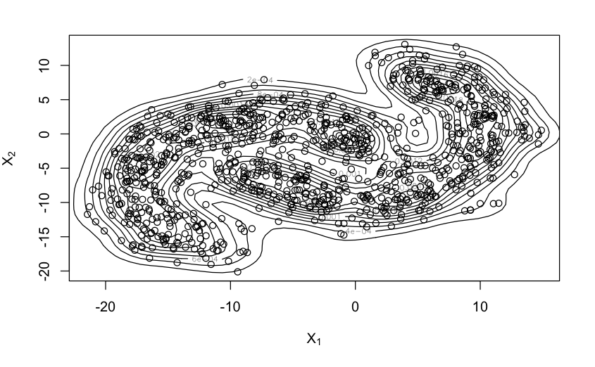

```r
library(KernSmooth)
x <- xy[,-pos]
dens.est <- bkde2D(x, bandwidth = sapply(x,dpik))
plot(x, xlab = expression(X[1]), ylab=expression(X[2]))
contour(x = dens.est$x1, y = dens.est$x2, z = dens.est$fhat, add = TRUE)
```

```r
  logistic.xy <- glm(as.factor(y)~., data=xy, family=binomial(link='logit'))
  summary(logistic.xy)
```

```
Call:
glm(formula = as.factor(y) ~ ., family = binomial(link = "logit"),
    data = xy)

Deviance Residuals:
     Min        1Q    Median        3Q       Max
-2.46094  -0.42442   0.02066   0.43186   2.26504

Coefficients:
            Estimate Std. Error z value Pr(>|z|)
(Intercept) -0.69705    0.11273  -6.184 6.27e-10 ***
X1          -0.30579    0.01829 -16.716  < 2e-16 ***
X2           0.14265    0.01685   8.466  < 2e-16 ***
---
Signif. codes:  0 ‘***’ 0.001 ‘**’ 0.01 ‘*’ 0.05 ‘.’ 0.1 ‘ ’ 1

(Dispersion parameter for binomial family taken to be 1)

    Null deviance: 1386.29  on 999  degrees of freedom
Residual deviance:  677.17  on 997  degrees of freedom
AIC: 683.17

Number of Fisher Scoring iterations: 6
```

```r
  aic.xy <- step(logistic.xy, scope=~., direction='both', k=2, trace=0)
  summary(aic.xy)
```

```
Call:
glm(formula = as.factor(y) ~ X1 + X2, family = binomial(link = "logit"),
    data = xy)

Deviance Residuals:
     Min        1Q    Median        3Q       Max
-2.46094  -0.42442   0.02066   0.43186   2.26504

Coefficients:
            Estimate Std. Error z value Pr(>|z|)
(Intercept) -0.69705    0.11273  -6.184 6.27e-10 ***
X1          -0.30579    0.01829 -16.716  < 2e-16 ***
X2           0.14265    0.01685   8.466  < 2e-16 ***
---
Signif. codes:  0 ‘***’ 0.001 ‘**’ 0.01 ‘*’ 0.05 ‘.’ 0.1 ‘ ’ 1

(Dispersion parameter for binomial family taken to be 1)

    Null deviance: 1386.29  on 999  degrees of freedom
Residual deviance:  677.17  on 997  degrees of freedom
AIC: 683.17

Number of Fisher Scoring iterations: 6
```

```r
  bic.xy <- step(logistic.xy, scope=~., direction='both', k=log(n), trace=0)
  summary(bic.xy)
```

```
Call:
glm(formula = as.factor(y) ~ X1 + X2, family = binomial(link = "logit"),
    data = xy)

Deviance Residuals:
     Min        1Q    Median        3Q       Max
-2.46094  -0.42442   0.02066   0.43186   2.26504

Coefficients:
            Estimate Std. Error z value Pr(>|z|)
(Intercept) -0.69705    0.11273  -6.184 6.27e-10 ***
X1          -0.30579    0.01829 -16.716  < 2e-16 ***
X2           0.14265    0.01685   8.466  < 2e-16 ***
---
Signif. codes:  0 ‘***’ 0.001 ‘**’ 0.01 ‘*’ 0.05 ‘.’ 0.1 ‘ ’ 1

(Dispersion parameter for binomial family taken to be 1)

    Null deviance: 1386.29  on 999  degrees of freedom
Residual deviance:  677.17  on 997  degrees of freedom
AIC: 683.17

Number of Fisher Scoring iterations: 6
```

Focus on the predictor ability to separate

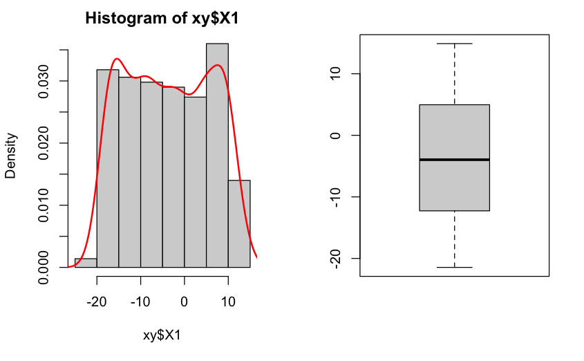

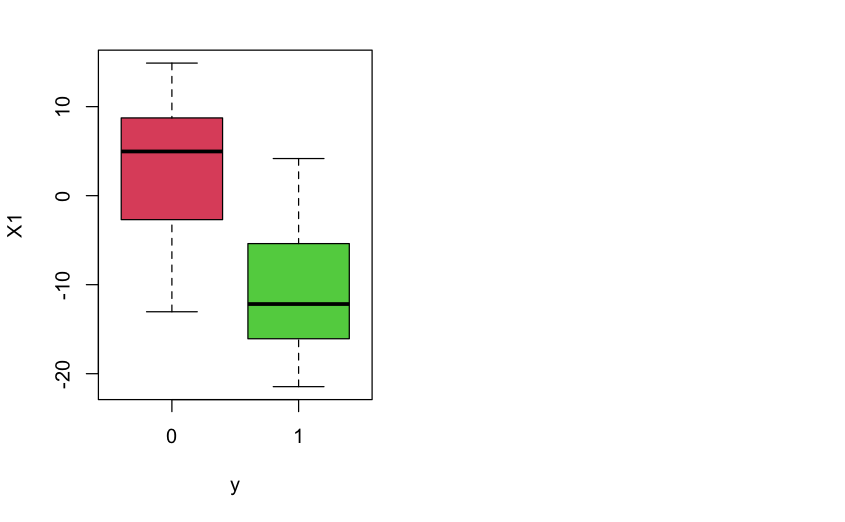

```r
   par(mfrow=c(1,2))
   hist(xy$X1, prob=T)
   lines(density(xy$X1), lwd=2, col='red')
   boxplot(xy$X1)

   par(mfrow=c(1,2))
   boxplot(X1~y, data=xy, col=2:3)

   boxplot(X2~y, data=xy, col=2:3)
```

SLBLR

```r
log.acc <- glm(as.factor(y)~X1, data=xy, family=binomial(link='logit'))
summary(log.acc)
```

```
Call:
glm(formula = as.factor(y) ~ X1, family = binomial(link = "logit"),
    data = xy)

Deviance Residuals:
     Min        1Q    Median        3Q       Max
-2.15734  -0.47405   0.01033   0.49965   2.03302

Coefficients:
            Estimate Std. Error z value Pr(>|z|)
(Intercept) -0.92452    0.10683  -8.654   <2e-16 ***
X1          -0.24145    0.01394 -17.318   <2e-16 ***
---
Signif. codes:  0 ‘***’ 0.001 ‘**’ 0.01 ‘*’ 0.05 ‘.’ 0.1 ‘ ’ 1

(Dispersion parameter for binomial family taken to be 1)

    Null deviance: 1386.29  on 999  degrees of freedom
Residual deviance:  760.02  on 998  degrees of freedom
AIC: 764.02

Number of Fisher Scoring iterations: 5
```

## Predictive performance of the 9-Nearest Neighbors Classifier

As you know by now, nearest neighbors learning machines are so-called lazy learners since there is no estimation per se in the traditional sense of storing a model. Instead, all the nearest neighbors machine does is perform predictions. If $\mathcal{Y}$ represents our output space and $\mathcal{X}$ represent our input space, and $\mathcal{V}_k(x)$ represents the set of the $k$ nearest neighbors of $x \in \mathcal{X}$ in the provided dataset $\mathcal{D}_n$, then the predicted class $\widehat{f}_{\tt kNN}(x)$ of $x \in \mathcal{X}$ is given by
$$\widehat{f}_{\tt kNN}(x) = \underset{c \in \mathcal{Y}}{{\tt argmax}}\Bigg\{\frac{1}{k}\sum_{i=1}^n{{\bf 1}(x_i \in \mathcal{V}_k(x)){\bf 1}(y_i=c)}\Bigg\}$$
Below, we start by considering the 9 nearest neighbors binary classifier on the test set, and the corresponding confusion matrix is generated

```r
  library(class)
  k        <- 9
  y.te     <- y[id.te]                                 # True responses in test set
  y.te.hat <- knn(x[id.tr,], x[id.te,], y[id.tr], k=k) # Predicted responses in test set

  conf.mat.te <- table(y.te, y.te.hat)
  conf.mat.te
```

```
    y.te.hat
y.te   0   1
   0 171   3
   1   4 156
```

We now consider a different and very special nearest neighbors learning machines, namely the 1 nearest neighbor or simply nearest neighbor learning machine. This time we first consider only the training set, and generate the corresponding confusion matrix

```r
  k        <- 1
  y.tr     <- y[id.tr]                                 # True responses in test set
  y.tr.hat <- knn(x[id.tr,], x[id.tr,], y[id.tr], k=k) # Predicted responses in test set

  conf.mat.tr <- table(y.tr, y.tr.hat)
  conf.mat.tr
```

```
    y.tr.hat
y.tr   0   1
   0 326   0
   1   0 340
```

We can see above something quite remarkable in the confusion matrix.

## Exercise

Explain why the off diagonal have the values observed Generate the 1NN test set confusion matrix

Below we set alternative ways of generating the very same quantities encountered earlier. This is provided here just for completeness and one can choose any of the ways to generate the predictive quantities of interest

```r
  pcc.te <- sum(diag(conf.mat.te))/nte
  # pcc.te <- 1-mean(ind.err.te)        # Another way from ind.err.te
  # pcc.te <- 1-length(id.err.te)/nte   # Yet another way fr
  pcc.te
```

```
[1] 0.9790419
```

```r
# Test Error

  err.te <- 1-pcc.te                    # Complement of accurary
  err.te
```

```
[1] 0.02095808
```

$$\widehat{R}^{(tr)}(\widehat{f})= \frac{1}{|\mathcal{D}_n^{(tr)}|}\sum_{i=1}^n{{\bf 1}(z_i \in \mathcal{D}_n^{(tr)}){\tt loss}(y_i, \widehat{f}(x_i))}$$
The corresponding test error is
$$\widehat{R}^{(te)}(\widehat{f})= \frac{1}{|\mathcal{D}_n^{(te)}|}\sum_{i=1}^n{{\bf 1}(z_i \in \mathcal{D}_n^{(te)}){\tt loss}(y_i, \widehat{f}(x_i))}$$
Where we also crucially have
$$\mathcal{D}_n^{(tr)} \cup \mathcal{D}_n^{(te)} = \mathcal{D}_n$$
So that
$$|\mathcal{D}_n^{(tr)}| + |\mathcal{D}_n^{(te)}| = |\mathcal{D}_n| = n.$$

The loss function used in the above errors is simply the famous zero-one loss, namely
$${\tt loss}(y, f(x)) = {\tt zeroone}(y, f(x)) = {\bf 1}(y\neq f(x))=
\left\{
\begin{array}{ll}
1 & \text{if}\,\, y \neq f(x) \\
0 & \text{if}\,\, y = f(x)
\end{array}\right.$$

## Receiver Operating Characteristics (ROC) Curves

We now turn to the creation of the very appealing graphic summary known as the ROC curve. This is arguably one of the best tools in binary classification as it allows the straightforward and very intuitive graphical way of assessing the predictive performance of a binary classifier. The ROC curve is built from two main ingredients, namely the True Positive Rate (TPR) and the False Positive Rate (FPR). For a given estimated learning machine $\widehat{f}$, we have

$${\tt TPR}(\widehat{f}) = \Pr(\widehat{f}(X)= +1 | Y = +1) = \frac{\Pr(\widehat{f}(X)=+1 \, \text{and} \, Y = +1) }{\Pr(Y = + 1)}$$
and

$${\tt FPR}(\widehat{f}) = \Pr(\widehat{f}(X)= +1 | Y = -1) = \frac{\Pr(\widehat{f}(X)=+1 \, \text{and} \, Y = -1) }{\Pr(Y = - 1)}$$
IN practice we neither have ${\tt FPR}(\widehat{f})$ nor ${\tt TPR}(\widehat{f})$, but instead their estimator $\widehat{{\tt FPR}(\widehat{f})}$ and $\widehat{{\tt TPR}(\widehat{f})}$ respectively.

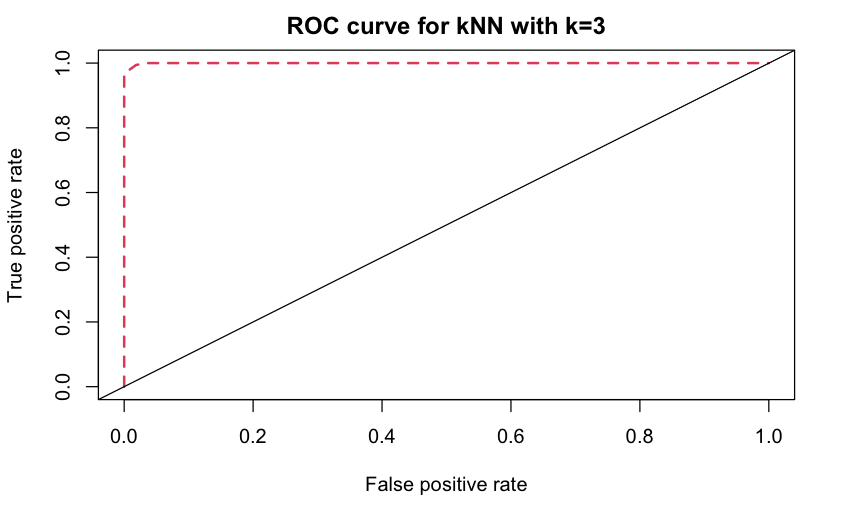

We now consider the creation of the ROC curves of our binary classifiers, but this time based on the training set

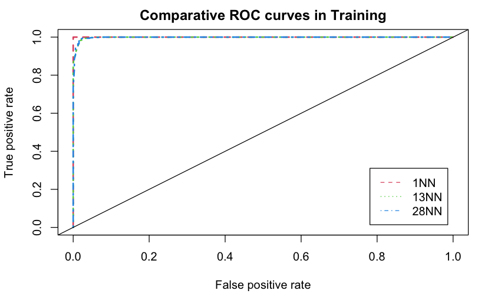

The comparatibve ROC curves based on the training set appear to declare the famous 1NN classifier the winner. However, this result is not valid, but the predictive comparisons are only truly meaningful if they are based on the test set.

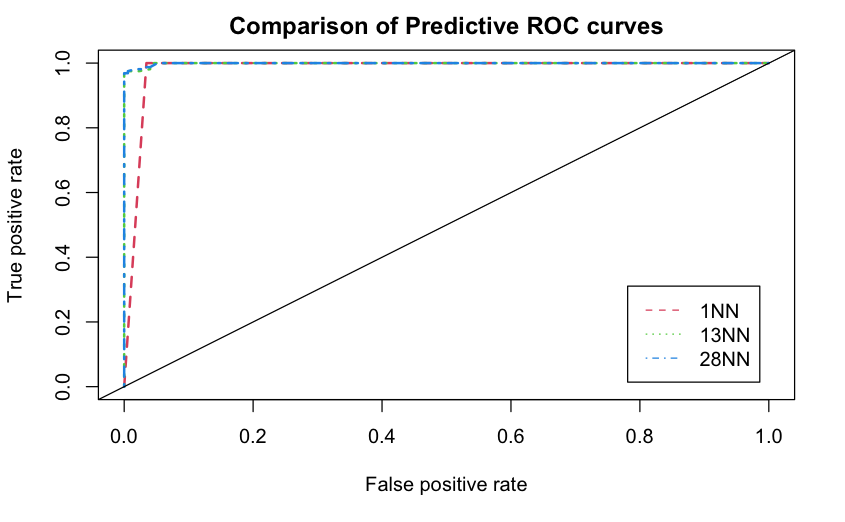

We see now from the above comparative ROC curves, that 1NN is no longer the winner. It’s apparent superior performance on the training set was most likely due to overfitting. This is an important lesson to learn, namely that one must base predictive comparisons on generalization which is mimic by the test set

### Comparing learning machines from different function spaces

```r
#
# Comparative ROC Curves on the test set
#
  library(ROCR)
  library(class)
  library(MASS)
  library(kernlab)
  library(rpart)
  library(ada)

  xy[,pos] <- as.factor(xy[,pos])

  y.roc   <- as.factor(y)

  # 1-Linear Discriminant Analysis

  lda.mod  <- lda(x[id.tr,], y.roc[id.tr])
  prob     <- predict(lda.mod, x[id.te,])$posterior[,2]
  pred.lda <- prediction(prob, y.roc[id.te])
  perf.lda <- performance(pred.lda, measure='tpr', x.measure='fpr')


  # 2-Quadratic Discriminant Analysis

  qda.mod  <- qda(x[id.tr,], y.roc[id.tr])
  prob     <- predict(qda.mod, x[id.te,])$posterior[,2]
  pred.qda <- prediction(prob, y.roc[id.te])
  perf.qda <- performance(pred.qda, measure='tpr', x.measure='fpr')


  # 3-Logistic Regression

  log.mod  <- glm(as.factor(y)~., data=xy[id.tr, ], family=binomial(link='logit'))
  prob     <- predict(log.mod, x[id.te,], type='response')  # Probabilities as prediction
  pred.log <- prediction(prob, y.roc[id.te])
  perf.log <- performance(pred.log, measure='tpr', x.measure='fpr')

  # 4-Naive Bayes
  library(naivebayes)
  naive.mod  <- naive_bayes(as.factor(y)~., data=xy[id.tr, ])
  prob       <- predict(naive.mod, x[id.te,], type='prob')[,2]  # Probabilities as prediction
  pred.naive <- prediction(prob, y.roc[id.te])
  perf.naive <- performance(pred.naive, measure='tpr', x.measure='fpr')

  # 5-Nearest Neighbors Learning Machine

  kNN.mod   <- class::knn(x[id.tr,], x[id.te,], y.roc[id.tr], k=12, prob=TRUE)
  prob      <- attr(kNN.mod, 'prob')
  prob      <- 2*ifelse(kNN.mod == "0", 1-prob, prob) - 1
  pred.kNN <- prediction(prob, y.roc[id.te])
  perf.kNN <- performance(pred.kNN, measure='tpr', x.measure='fpr')

  # 6-Support Vector Machines

  svm.mod  <- ksvm(as.factor(y)~., data=xy[id.tr, ], kernel='rbfdot', type='C-svc', prob.model=TRUE)
  prob     <- predict(svm.mod, x[id.te, ], type='probabilities')[,2]
  pred.svm <- prediction(prob, y.roc[id.te])
  perf.svm <- performance(pred.svm, measure='tpr', x.measure='fpr')

  # 7-Classification Trees

  tree.mod  <- rpart(as.factor(y)~., data=xy[id.tr, ])
  prob      <- predict(tree.mod, x[id.te, ], type='prob')[,2]
  pred.tree <- prediction(prob, y.roc[id.te])
  perf.tree <- performance(pred.tree, measure='tpr', x.measure='fpr')


  # 8-Random Forest
  library(randomForest)
  rf.mod    <- randomForest(as.factor(y)~., data=xy[id.tr, ])
  prob      <- predict(rf.mod, x[id.te, ], type='prob')[,2]
  pred.rf   <- prediction(prob, y.roc[id.te])
  perf.rf   <- performance(pred.rf, measure='tpr', x.measure='fpr')

  # 9-Stochastic Adaptive Boosting

  boost.mod   <- ada(as.factor(y)~., data=xy[id.tr, ])
  prob        <- predict(boost.mod, x[id.te, ], type='probs')[,2]
  pred.boost  <- prediction(prob, y.roc[id.te])
  perf.boost  <- performance(pred.boost, measure='tpr', x.measure='fpr')

  # 10-Gaussian Processes

  gp.mod    <- gausspr(as.factor(y)~., data=xy[id.tr, ], type='classification', kernel='rbfdot')
  prob      <- predict(gp.mod, x[id.te, ], type='prob')[,2]
  pred.gp   <- prediction(prob, y.roc[id.te])
  perf.gp   <- performance(pred.gp, measure='tpr', x.measure='fpr')

  plot(perf.lda, col=2, lwd= 2, lty=1, main=paste('Comparison of Predictive ROC curves'))
  plot(perf.qda, col=3, lwd= 2, lty=1, add=TRUE)
  plot(perf.log, col=4, lwd= 2, lty=1, add=TRUE)
  plot(perf.naive, col=5, lwd= 2, lty=1, add=TRUE)
  plot(perf.kNN, col=6, lwd= 2, lty=1, add=TRUE)
  plot(perf.svm, col=7, lwd= 2, lty=1, add=TRUE)
  plot(perf.tree, col=8, lwd= 2, lty=1, add=TRUE)
  plot(perf.rf, col=9, lwd= 2, lty=1, add=TRUE)
  plot(perf.boost, col=10, lwd= 2, lty=1, add=TRUE)
  plot(perf.gp, col=11, lwd= 2, lty=1, add=TRUE)
  abline(a=0,b=1)
  legend('bottomright', inset=0.05, c('LDA','QDA', 'LOG', 'NB', 'kNN','SVM','TREE', 'RF','BOOST','GP'),
         col=2:11, lty=1)
```

[output not shown]

## Cross Validation for Selection Models within a Function Space

Within the implicit function space from which each of the k Nearest Neighbors machines are chosen, it is of great interest to find a strategy or a least a criterion for choosing a member of the space, in this case the size of the neighborhood $k$. It turns out that cross validation does allow us to determine the neighborhood size $k$.

$${\tt CV}(\widehat{f}) = \frac{1}{V}\sum_{v=1}^{V}{\widehat{e}_v(\widehat{f})}$$
where the $v^{th}$ cross validated error $\widehat{e}_v(\widehat{f})$, is the error made by $\widehat{f}$ on the $v^{th}$ chunk of the $\mathcal{D}_n$, with that left out chunk not having been used in the training of $\widehat{f}$, ie
$$\widehat{e}_v(\widehat{f}) = \frac{1}{|\mathcal{D}_n^{(v)}|}\sum_{i=1}^n{\mathbf{1}(z_i \in \mathcal{D}_n^{(v)}){\tt loss}(y_i,\widehat{f}^{(-v)}(x_i))}$$
where $z_i=(x_i, y_i)$ and $\widehat{f}^{(-v)}(\cdot)$ is estimator $\widehat{f}$ obtained on data without the $v^{th}$ chunk $\mathcal{D}_n^{(v)}$.

```r
  xtr <- x #x[id.tr,]          # Using the only the training for validation
  ytr <- y #y[id.tr]           # We could use the entire sample but that's greedy

  vK <- seq(1, 25, by=1)    # Grid of values of k
  nK <- length(vK)          # Number of values of k considered
  cv.error <-numeric(nK)    # Vector of cross validation errors for each k
  nc <- nrow(xtr)           # Number of observations used for cross validation
  c   <- 10                 # Number of folds. We are doing c-fold cross validation

  S   <- sample(sample(nc)) # We randomly shuffle the data before starting CV
  m   <- ceiling(nc/c)      # Maximum Number of observations in each fold

  held.out.set <- matrix(0, nrow=c, ncol=m) # Table used to track the evolution

  for(ic in 1:(c-1))
  {
    held.out.set[ic,] <- S[((ic-1)*m + 1):(ic*m)]
  }
  held.out.set[c, 1:(nc-(c-1)*m)] <- S[((c-1)*m + 1):nc]  # Handling last chunk just in case n!=mc

#
# Running the cross validation itself
#
  for(j in 1:nK)
  {
    for(i in 1:c)
    {
      out <-  held.out.set[i,]
      yhatc<- knn(xtr[-out,], xtr[out,],ytr[-out],  k=vK[j])
      cv.error[j]<-cv.error[j] + (length(out)-sum(diag(table(ytr[out],yhatc))))/length(out)
    }
    cv.error[j]<-cv.error[j]/c
  }

#
# Plot the cross validation curve
#
  plot(vK, cv.error, xlab='k', ylab=expression(CV[Error](k)),
      main='Choice of k in k Nearest Neighbor by m-fold Cross Validation')
  lines(vK, cv.error, type='c')
```

[output not shown]

For a nicer looking plot, we resort to the famous ggplot

```r
#
#  Nicer plot with ggplot2
#
  library(ggplot2)

  cv <- data.frame(vK, cv.error)
  colnames(cv) <- c('k','error')

  ggplot(cv, aes(k,error))+geom_point()+geom_line()+
    labs(x='k=size of neighborhood', y=expression(CV[Error](k)))
```

[output not shown]

## Predictive performance using stochastic hold out

Once members of various function spaces are chosen using perhaps cross validation as above, it becomes interesting to compare several methods via many copies of their test errors generated randomly via stochastic hold out. We first do it for a single learning machine and then we move on to several different learning machines

```r
#
# Extract the optimal k yielded by cross validation
#
  k.opt.cv <- 9 #max(which(cv.error==min(cv.error)))

##############################################################
# Using the optimally tuned k let's estimate the test error  #
##############################################################

  set.seed (19671210)          # Set seed for random number generation to be reproducible

  epsilon <- 1/3               # Proportion of observations in the test set
  nte     <- round(n*epsilon)  # Number of observations in the test set
  ntr     <- n - nte

  #k.opt.cv <- 28

  R <- 100   # Number of replications
  test.err <- numeric(R)

  for(r in 1:R)
  {
    # Split the data

    hold <- stratified.holdout(as.factor(xy[,pos]), 1-epsilon)
    id.tr <- hold$idx1
    id.te <- hold$idx2
    ntr   <- length(id.tr)
    nte   <- length(id.te)

    y.te         <- y[id.te]                    # True responses in test set
    y.te.hat     <- knn(x[id.tr,], x[id.te,], y[id.tr], k=k.opt.cv) # Predicted responses in test set
    ind.err.te   <- ifelse(y.te!=y.te.hat,1,0)    # Random variable tracking error. Indicator
    test.err[r]  <- mean(ind.err.te)
  }

  test <- data.frame(test.err)
  colnames(test) <- c('error')

  ggplot(test, aes(x='', y=error))+geom_boxplot()+
  labs(x='Method', y=expression(hat(R)[te](kNN)))

  ##############################################################
  #  Predictively compare different kNN  learning machines     #
  ##############################################################
```

[output not shown]

```r
  set.seed (19671210)          # Set seed for random number generation to be reproducible

  epsilon <- 1/3               # Proportion of observations in the test set

  R <- 50   # Number of replications
  test.err <- matrix(0, nrow=R, ncol=11)

  library(class)

  for(r in 1:R)
  {
    # Split the data

    hold <- stratified.holdout(as.factor(xy[,pos]), 1-epsilon)
    id.tr <- hold$idx1
    id.te <- hold$idx2
    ntr   <- length(id.tr)
    nte   <- length(id.te)

    y.te         <- y[id.te]                            # True responses in test set

    # 1-Linear Discriminant Analysis

    lda.mod        <- lda(x[id.tr,], y.roc[id.tr])
    y.te.hat       <- predict(lda.mod, x[id.te,])$class
    ind.err.te     <- ifelse(y.te!=y.te.hat,1,0)    # Random variable tracking error. Indicator
    test.err[r,1]  <- mean(ind.err.te)

    # 2-Quadratic Discriminant Analysis

    qda.mod        <- qda(x[id.tr,], y.roc[id.tr])
    y.te.hat       <- predict(qda.mod, x[id.te,])$class
    ind.err.te     <- ifelse(y.te!=y.te.hat,1,0)                      # Random variable tracking error. Indicator
    test.err[r,2]  <- mean(ind.err.te)

    # 3-Logistic Regression

    log.mod        <- glm(as.factor(y)~., data=xy[id.tr, ], family=binomial(link='logit'))
    y.te.hat       <- as.factor(ifelse(predict(log.mod, x[id.te,], type='response')>0.5,1,0))
    ind.err.te     <- ifelse(y.te!=y.te.hat,1,0)                      # Random variable tracking error. Indicator
    test.err[r,3]  <- mean(ind.err.te)

    # 4-Naive Bayes

    naive.mod      <- naive_bayes(as.factor(y)~., data=xy[id.tr, ])
    y.te.hat       <- predict(naive.mod, x[id.te,], type='class')
    ind.err.te     <- ifelse(y.te!=y.te.hat,1,0)                      # Random variable tracking error. Indicator
    test.err[r,4]  <- mean(ind.err.te)

    # 5-Nearest Neighbors Learning Machine

    y.te.hat       <- knn(x[id.tr,], x[id.te,], y.roc[id.tr], k=12, prob=TRUE)
    ind.err.te     <- ifelse(y.te!=y.te.hat,1,0)  # Random variable tracking error. Indicator
    test.err[r,5]  <- mean(ind.err.te)

    # 6-Support Vector Machines

    svm.mod        <- ksvm(as.factor(y)~., data=xy[id.tr, ], kernel='rbfdot', type='C-svc', prob.model=TRUE)
    y.te.hat       <- predict(svm.mod, x[id.te, ], type='response')
    ind.err.te     <- ifelse(y.te!=y.te.hat,1,0)  # Random variable tracking error. Indicator
    test.err[r,6]  <- mean(ind.err.te)

    # 7-Classification Trees

    tree.mod       <- rpart(as.factor(y)~., data=xy[id.tr, ])
    y.te.hat       <- predict(tree.mod, x[id.te, ], type='class')
    ind.err.te     <- ifelse(y.te!=y.te.hat,1,0)  # Random variable tracking error. Indicator
    test.err[r,7]  <- mean(ind.err.te)

    # 8-Random Forest

    rf.mod         <- randomForest(as.factor(y)~., data=xy[id.tr, ])
    y.te.hat       <- predict(rf.mod, x[id.te, ], type='response')
    ind.err.te     <- ifelse(y.te!=y.te.hat,1,0)   # Random variable tracking error. Indicator
    test.err[r,8]  <- mean(ind.err.te)

    # 9-Stochastic Adaptive Boosting

    boost.mod      <- ada(as.factor(y)~., data=xy[id.tr, ])
    y.te.hat       <- predict(boost.mod, x[id.te, ], type='vector')
    ind.err.te     <- ifelse(y.te!=y.te.hat,1,0)  # Random variable tracking error. Indicator
    test.err[r,9]  <- mean(ind.err.te)

    # 10-Gaussian Processes

    gp.mod         <- gausspr(as.factor(y)~., data=xy[id.tr, ], type='classification', kernel='rbfdot')
    y.te.hat       <- predict(gp.mod, x[id.te, ], type='response')
    ind.err.te     <- ifelse(y.te!=y.te.hat,1,0)  # Random variable tracking error. Indicator
    test.err[r,10] <- mean(ind.err.te)

    # 11-Bagging

    bagging.mod    <- bagging(as.factor(y)~., data=xy[id.tr, ], mfinal=5)
    y.te.hat       <- predict(bagging.mod, x[id.te, ], type='class')
    ind.err.te     <- ifelse(y.te!=y.te.hat,1,0)    # Random variable tracking error. Indicator
    test.err[r,11] <- mean(ind.err.te)

    # 12-Neural Networks
    #library(nnet)
    #nnet.mod       <- nnet(as.factor(y)~., data=xy[id.tr, ], size=15)
    #y.te.hat       <- as.factor(ifelse(predict(nnet.mod, x[id.te,], type='class')==1,1,0))
    #ind.err.te     <- ifelse(y.te!=y.te.hat,1,0)   # Random variable tracking error. Indicator
    #test.err[r,12] <- mean(ind.err.te)
  }

  test <- data.frame(test.err)
  Method<-c('LDA','QDA', 'LOG', 'NB', 'kNN','SVM','TREE', 'RF','BOOST','GP', 'BAG')
  colnames(test) <- Method
  boxplot(test)
```

[output not shown]

We can also explore the accuracy

```r
  accu <- data.frame(1-test.err)
  Method<-c('LDA','QDA', 'LOG', 'NB', 'kNN','SVM','TREE', 'RF','BOOST','GP', 'BAG')
  colnames(accu) <- Method
  boxplot(accu)
```

[output not shown]

Once again, we also produce a nicer looking version of the same plot using the famous ggplot

```r
  require(reshape2)
  ggplot(data = melt(test), aes(x=variable, y=value)) + geom_boxplot(aes(fill=variable))+
    labs(x='Method', y=expression(hat(A)[te](hat(f))))+
    theme(legend.position="none")
```

[output not shown]

Enjoying ggplot for accuracy

```r
  require(reshape2)
  ggplot(data = melt(accu), aes(x=variable, y=value)) + geom_boxplot(aes(fill=variable))+
    labs(x='Method', y=expression(hat(P)[te](hat(f))))+
    theme(legend.position="none")
```

[output not shown]

## Analysis of Variance

From a purely statistical perspective, it often becomes important to perform the inferential method of analysis of variance to more rigorously and more formally compare the learning machines under consideration

```r
#
# Is the difference between the methods significant
#
  aov.method <- aov(value~variable, data=melt(test))
  anova(aov.method)
  #summary(aov.method)

  TukeyHSD(aov.method, ordered = TRUE)
  plot(TukeyHSD(aov.method))
```

[output not shown]